# Course8Project

John David

8/23/2019

## Weight Lifting - Machine Learning Project

Using devices such as Jawbone Up, Nike FuelBand, and Fitbit it is now possible to collect a large amount of data about personal activity relatively inexpensively. These type of devices are part of the quantified self movement – a group of enthusiasts who take measurements about themselves regularly to improve their health, to find patterns in their behavior, or because they are tech geeks. One thing that people regularly do is quantify how much of a particular activity they do, but they rarely quantify how well they do it. In this project, your goal will be to use data from accelerometers on the belt, forearm, arm, and dumbell of 6 participants. They were asked to perform barbell lifts correctly and incorrectly in 5 different ways. More information is available from the website here: http://web.archive.org/web/20161224072740/http:/groupware.les.inf.puc-rio.br/har (see the section on the Weight Lifting Exercise Dataset).

Conclusion: It was fun to analyze the data myself but I could have used the randomforest to do it. All in all I enjoyed this lab and used all my previous John Hopkins classes to find this success.

References: http://www-personal.umich.edu/~johannb/Papers/paper63.pdf https://www.google.com/search?q=pitch+roll+and+yaw&tbm=isch&source=iu&ictx=1&fir=4R5jctF0uP_q5M%253A%252CrwdN0Ut4Lf6FUM%252C%252Fm%252F04gmp6w&vet=1&usg=AI4_-kR4vLK3GkH5rhntURhlMELz4kTd0g&sa=X&ved=2ahUKEwiF-4jEhZnkAhVldt8KHU2fB3UQ_B0wG3oECAEQAw#imgrc=4R5jctF0uP_q5M:

```r
library("dplyr")
```

```r
library("ggplot2")
library("mlbench")
library("caret")
#library("MASS")
library("randomForest")
trainingDF <- read.csv(file="/Users/douglasashworth/Documents/coursera/DataScience/Course8MachineLearning/pml-training.csv", stringsAsFactors = FALSE)

#summary(trainingDF)
#str(trainingDF)
names(trainingDF)
```

```
##   [1] "X"                        "user_name"
##   [3] "raw_timestamp_part_1"     "raw_timestamp_part_2"
##   [5] "cvtd_timestamp"           "new_window"
##   [7] "num_window"               "roll_belt"
##   [9] "pitch_belt"               "yaw_belt"
##  [11] "total_accel_belt"         "kurtosis_roll_belt"
##  [13] "kurtosis_picth_belt"      "kurtosis_yaw_belt"
##  [15] "skewness_roll_belt"       "skewness_roll_belt.1"
##  [17] "skewness_yaw_belt"        "max_roll_belt"
##  [19] "max_picth_belt"           "max_yaw_belt"
##  [21] "min_roll_belt"            "min_pitch_belt"
##  [23] "min_yaw_belt"             "amplitude_roll_belt"
##  [25] "amplitude_pitch_belt"     "amplitude_yaw_belt"
##  [27] "var_total_accel_belt"     "avg_roll_belt"
##  [29] "stddev_roll_belt"         "var_roll_belt"
```

[output cut: 65 more lines]

```r
str(trainingDF)
```

```
## 'data.frame':    19622 obs. of  160 variables:
##  $ X                       : int  1 2 3 4 5 6 7 8 9 10 ...
##  $ user_name               : chr  "carlitos" "carlitos" "carlitos" "carlitos" ...
##  $ raw_timestamp_part_1    : int  1323084231 1323084231 1323084231 1323084232 1323084232 1323084232 1323084232 1323084232 1323084232 1323084232 ...
##  $ raw_timestamp_part_2    : int  788290 808298 820366 120339 196328 304277 368296 440390 484323 484434 ...
##  $ cvtd_timestamp          : chr  "05/12/2011 11:23" "05/12/2011 11:23" "05/12/2011 11:23" "05/12/2011 11:23" ...
##  $ new_window              : chr  "no" "no" "no" "no" ...
##  $ num_window              : int  11 11 11 12 12 12 12 12 12 12 ...
##  $ roll_belt               : num  1.41 1.41 1.42 1.48 1.48 1.45 1.42 1.42 1.43 1.45 ...
##  $ pitch_belt              : num  8.07 8.07 8.07 8.05 8.07 8.06 8.09 8.13 8.16 8.17 ...
##  $ yaw_belt                : num  -94.4 -94.4 -94.4 -94.4 -94.4 -94.4 -94.4 -94.4 -94.4 -94.4 ...
##  $ total_accel_belt        : int  3 3 3 3 3 3 3 3 3 3 ...
##  $ kurtosis_roll_belt      : chr  "" "" "" "" ...
##  $ kurtosis_picth_belt     : chr  "" "" "" "" ...
##  $ kurtosis_yaw_belt       : chr  "" "" "" "" ...
```

[output cut: 86 more lines]

## Lets explore the data and see if we can build the model features via a set of box plot and some common sense

```r
################################ Exploring the Data ######################################

plotDF <- trainingDF
plotDF$classe <- as.factor(plotDF$classe)
str(plotDF)
```

[output not shown]

[output cut: 86 more lines]

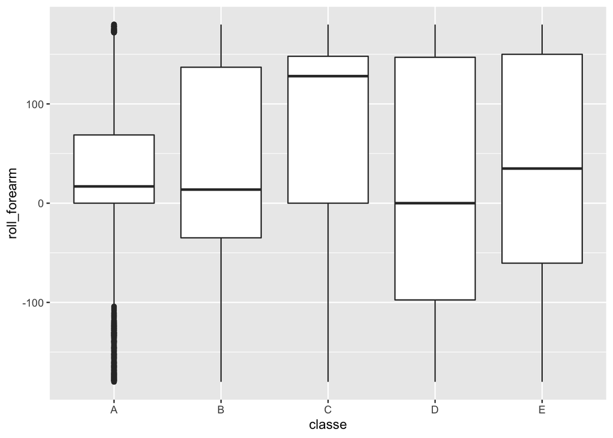

```r
#print(names(plotDF))

bxpRFA <- ggplot(plotDF,aes(x=classe,y=roll_forearm)) + geom_boxplot()
plot(bxpRFA)
```

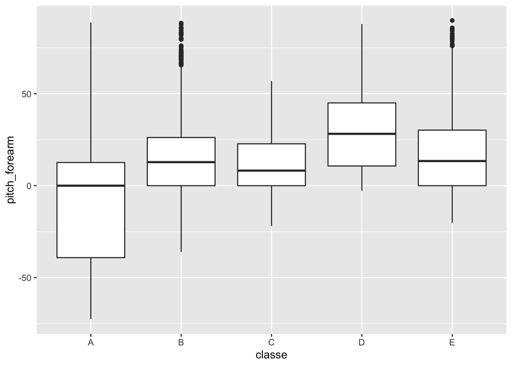

```r
bxpPFA <- ggplot(plotDF,aes(x=classe,y=pitch_forearm)) + geom_boxplot()
plot(bxpPFA)
```

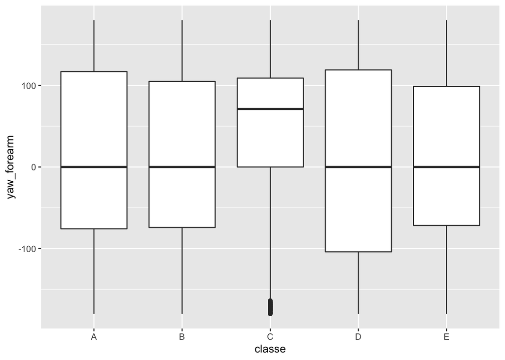

```r
bxpYFA <- ggplot(plotDF,aes(x=classe,y=yaw_forearm)) + geom_boxplot()
plot(bxpYFA)
```

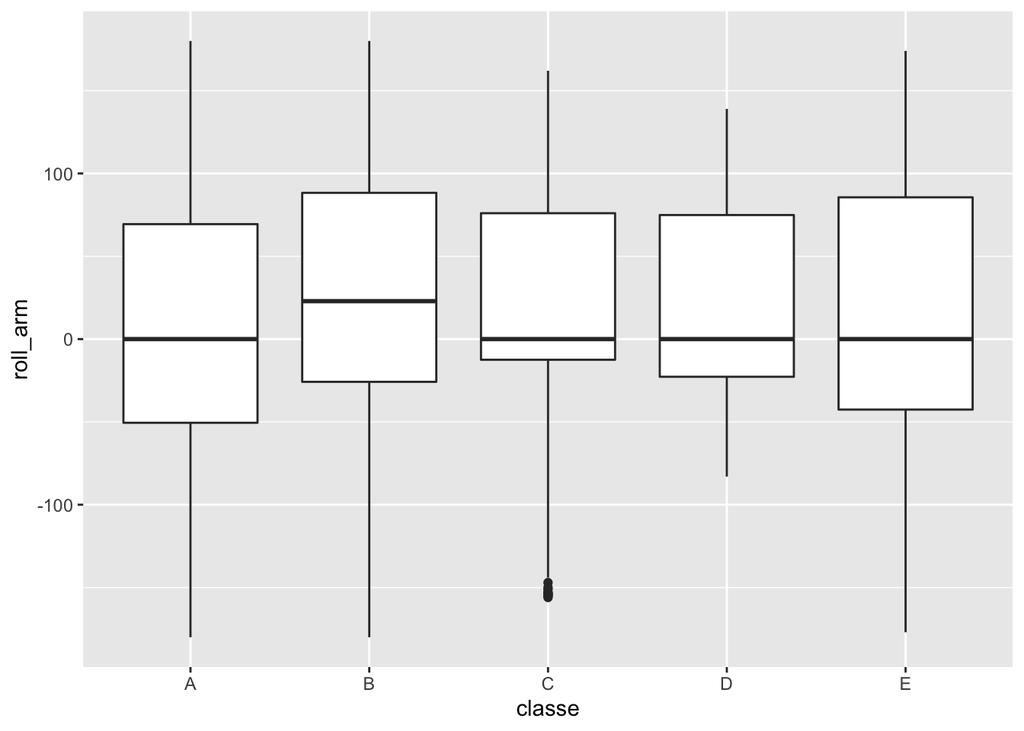

```r
bxpRA <- ggplot(plotDF,aes(x=classe,y=roll_arm)) + geom_boxplot()
plot(bxpRA)
```

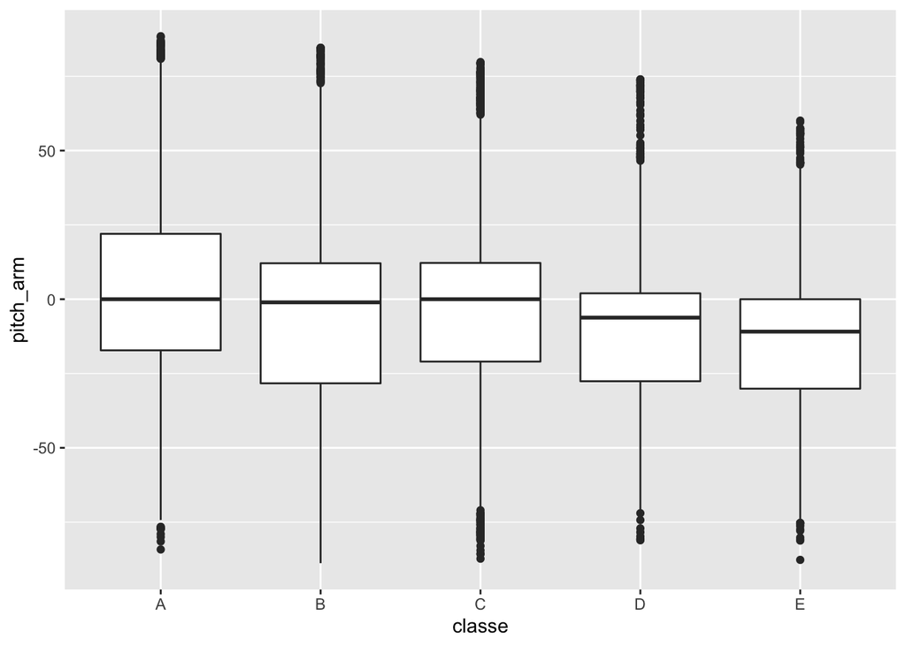

```r
bxpPA <- ggplot(plotDF,aes(x=classe,y=pitch_arm)) + geom_boxplot()
plot(bxpPA)
```

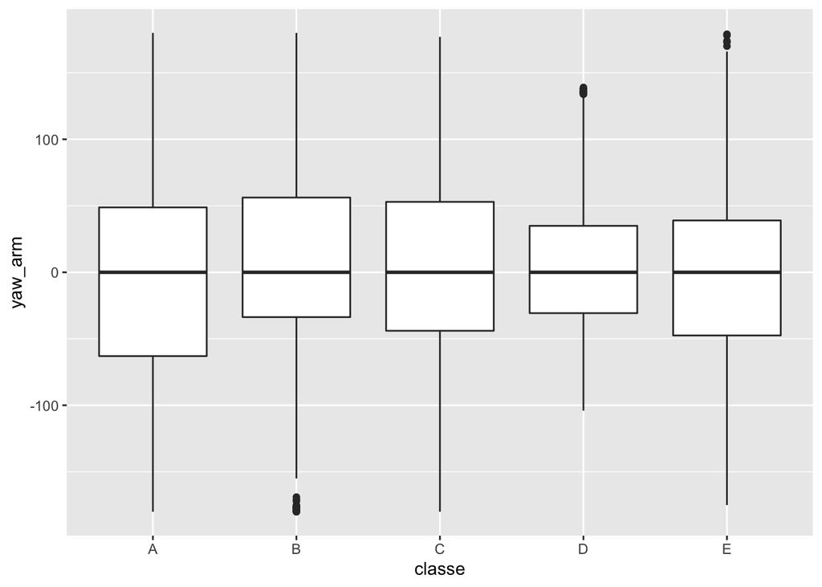

```r
bxpYA <- ggplot(plotDF,aes(x=classe,y=yaw_arm)) + geom_boxplot()
plot(bxpYA)
```

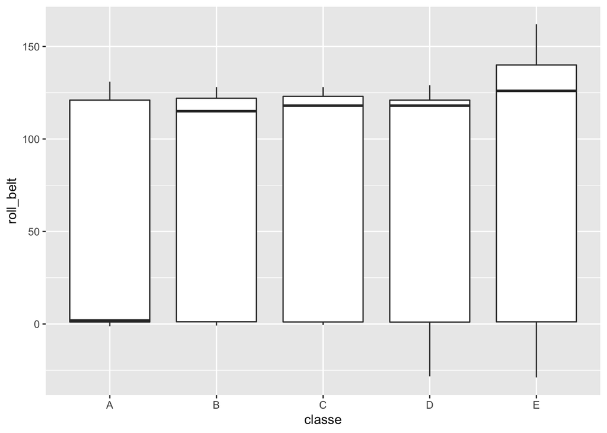

```r
bxpRB <- ggplot(plotDF,aes(x=classe,y=roll_belt)) + geom_boxplot()
plot(bxpRB)
```

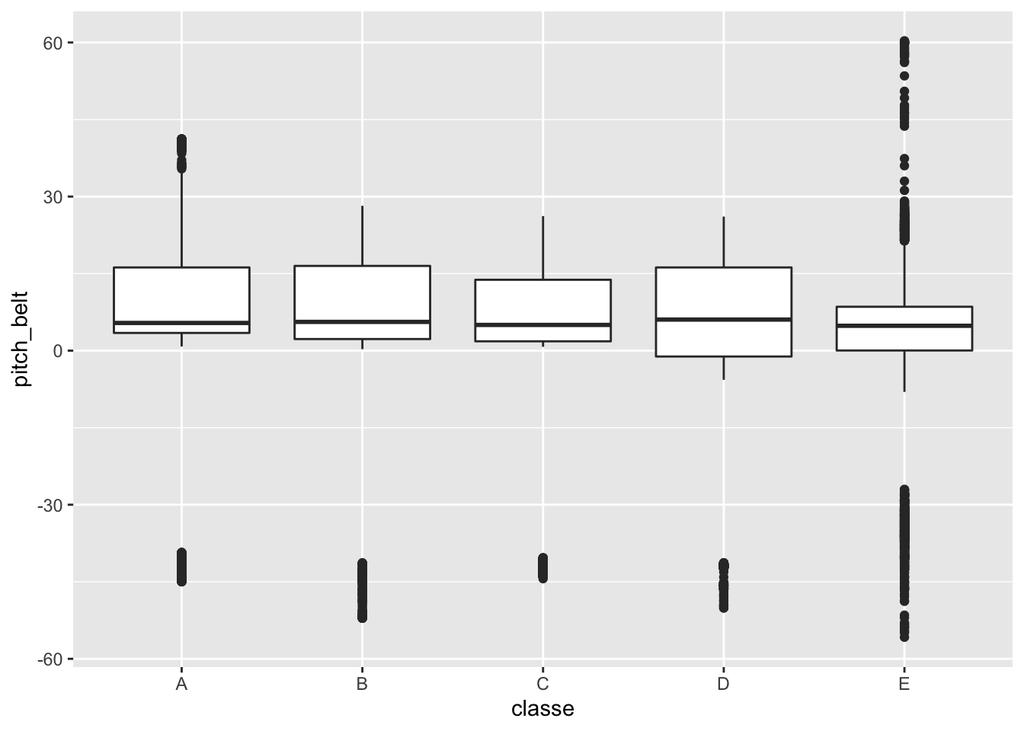

```r
bxpPB <- ggplot(plotDF,aes(x=classe,y=pitch_belt)) + geom_boxplot()
plot(bxpPB)
```

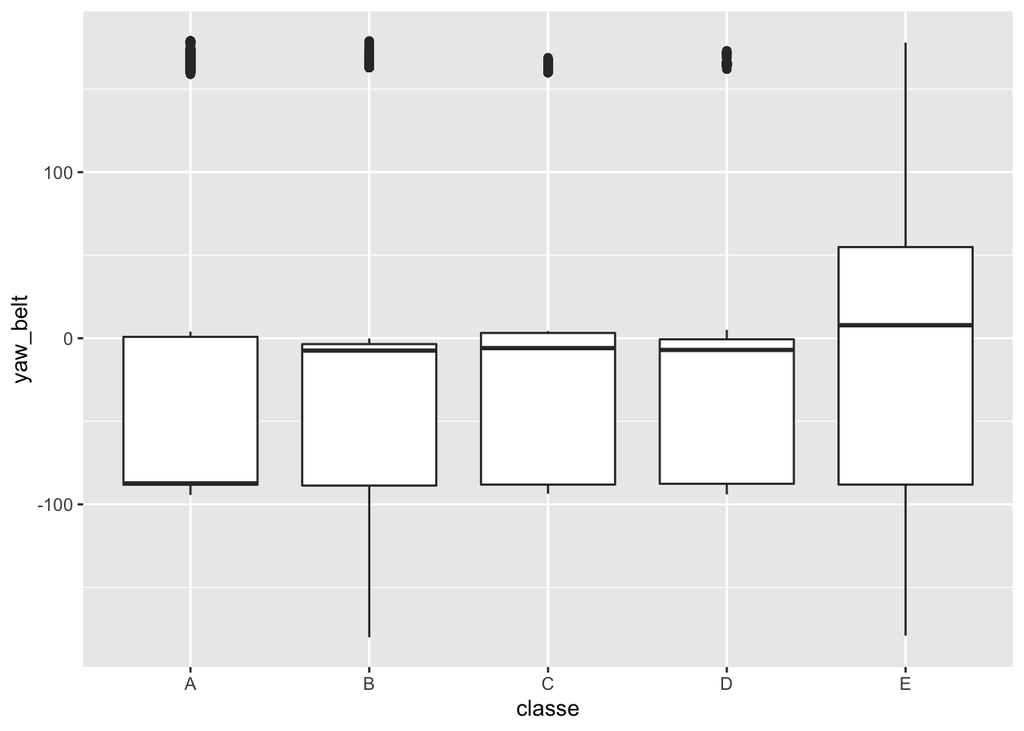

```r
bxpYB <- ggplot(plotDF,aes(x=classe,y=yaw_belt)) + geom_boxplot()
plot(bxpYB)
```

```r
selectedInputDF = select(trainingDF, roll_forearm, pitch_forearm, yaw_forearm, roll_arm, pitch_arm, yaw_arm, roll_belt, pitch_belt, yaw_belt, classe)

str(selectedInputDF)
```

```
## 'data.frame':    19622 obs. of  10 variables:
##  $ roll_forearm : num  28.4 28.3 28.3 28.1 28 27.9 27.9 27.8 27.7 27.7 ...
##  $ pitch_forearm: num  -63.9 -63.9 -63.9 -63.9 -63.9 -63.9 -63.9 -63.8 -63.8 -63.8 ...
##  $ yaw_forearm  : num  -153 -153 -152 -152 -152 -152 -152 -152 -152 -152 ...
##  $ roll_arm     : num  -128 -128 -128 -128 -128 -128 -128 -128 -128 -128 ...
##  $ pitch_arm    : num  22.5 22.5 22.5 22.1 22.1 22 21.9 21.8 21.7 21.6 ...
##  $ yaw_arm      : num  -161 -161 -161 -161 -161 -161 -161 -161 -161 -161 ...
##  $ roll_belt    : num  1.41 1.41 1.42 1.48 1.48 1.45 1.42 1.42 1.43 1.45 ...
##  $ pitch_belt   : num  8.07 8.07 8.07 8.05 8.07 8.06 8.09 8.13 8.16 8.17 ...
##  $ yaw_belt     : num  -94.4 -94.4 -94.4 -94.4 -94.4 -94.4 -94.4 -94.4 -94.4 -94.4 ...
##  $ classe       : chr  "A" "A" "A" "A" ...
```

```r
selectedInputDF$classe <- as.factor(selectedInputDF$classe)
#testClasse <- c()
#for (k in 1:nrow(selectedTestInputDF)){
#  testClasse <- c(testClasse,"NA")
#}

#selectedTestInputDF <- cbind(selectedTestInputDF,testClasse)
#selectedTestInputDF$testClasse <- as.factor(selectedTestInputDF$testClasse)

head(selectedInputDF,10)
```

```
##    roll_forearm pitch_forearm yaw_forearm roll_arm pitch_arm yaw_arm
## 1          28.4         -63.9        -153     -128      22.5    -161
## 2          28.3         -63.9        -153     -128      22.5    -161
## 3          28.3         -63.9        -152     -128      22.5    -161
## 4          28.1         -63.9        -152     -128      22.1    -161
## 5          28.0         -63.9        -152     -128      22.1    -161
## 6          27.9         -63.9        -152     -128      22.0    -161
## 7          27.9         -63.9        -152     -128      21.9    -161
## 8          27.8         -63.8        -152     -128      21.8    -161
## 9          27.7         -63.8        -152     -128      21.7    -161
## 10         27.7         -63.8        -152     -128      21.6    -161
##    roll_belt pitch_belt yaw_belt classe
## 1       1.41       8.07    -94.4      A
## 2       1.41       8.07    -94.4      A
## 3       1.42       8.07    -94.4      A
## 4       1.48       8.05    -94.4      A
## 5       1.48       8.07    -94.4      A
## 6       1.45       8.06    -94.4      A
## 7       1.42       8.09    -94.4      A
## 8       1.42       8.13    -94.4      A
## 9       1.43       8.16    -94.4      A
## 10      1.45       8.17    -94.4      A
```

```r
tail(selectedInputDF)
```

```
##       roll_forearm pitch_forearm yaw_forearm roll_arm pitch_arm yaw_arm
## 19617            0             0           0    -99.1     -33.7    79.4
## 19618            0             0           0    -99.4     -33.8    79.0
## 19619            0             0           0    -99.6     -34.5    77.3
## 19620            0             0           0    -99.6     -35.1    76.3
## 19621            0             0           0    -98.6     -36.7    73.5
## 19622            0             0           0    -97.6     -37.7    71.5
##       roll_belt pitch_belt yaw_belt classe
## 19617       148      -34.7      129      E
## 19618       147      -34.8      129      E
## 19619       145      -35.3      130      E
## 19620       145      -35.5      130      E
## 19621       143      -35.9      131      E
## 19622       143      -36.0      132      E
```

```r
#str(selectedInputDF)

finalDF <- selectedInputDF

################################ Random Forest #################################3

# Split the data into training and validation sets

DF51 <- finalDF[,1:9]
DF52 <- finalDF[,10]
names(DF51)
```

```
## [1] "roll_forearm"  "pitch_forearm" "yaw_forearm"   "roll_arm"
## [5] "pitch_arm"     "yaw_arm"       "roll_belt"     "pitch_belt"
## [9] "yaw_belt"
```

```r
names(DF52)
```

[output not shown]

```r
rndForestDF <- finalDF
names(rndForestDF)
```

```
##  [1] "roll_forearm"  "pitch_forearm" "yaw_forearm"   "roll_arm"
##  [5] "pitch_arm"     "yaw_arm"       "roll_belt"     "pitch_belt"
##  [9] "yaw_belt"      "classe"
```

```r
str(rndForestDF)
```

```
## 'data.frame':    19622 obs. of  10 variables:
##  $ roll_forearm : num  28.4 28.3 28.3 28.1 28 27.9 27.9 27.8 27.7 27.7 ...
##  $ pitch_forearm: num  -63.9 -63.9 -63.9 -63.9 -63.9 -63.9 -63.9 -63.8 -63.8 -63.8 ...
##  $ yaw_forearm  : num  -153 -153 -152 -152 -152 -152 -152 -152 -152 -152 ...
##  $ roll_arm     : num  -128 -128 -128 -128 -128 -128 -128 -128 -128 -128 ...
##  $ pitch_arm    : num  22.5 22.5 22.5 22.1 22.1 22 21.9 21.8 21.7 21.6 ...
##  $ yaw_arm      : num  -161 -161 -161 -161 -161 -161 -161 -161 -161 -161 ...
##  $ roll_belt    : num  1.41 1.41 1.42 1.48 1.48 1.45 1.42 1.42 1.43 1.45 ...
##  $ pitch_belt   : num  8.07 8.07 8.07 8.05 8.07 8.06 8.09 8.13 8.16 8.17 ...
##  $ yaw_belt     : num  -94.4 -94.4 -94.4 -94.4 -94.4 -94.4 -94.4 -94.4 -94.4 -94.4 ...
##  $ classe       : Factor w/ 5 levels "A","B","C","D",..: 1 1 1 1 1 1 1 1 1 1 ...
```

```r
set.seed(325)
data_set_size = floor(nrow(selectedInputDF)*0.70)
index <- sample(1:nrow(selectedInputDF),size = data_set_size)
train <- selectedInputDF[index,]
test <- selectedInputDF[-index,]

set.seed(757)
rf <- randomForest(classe ~ .,data=train, ntree = 150,mtry=3,importance=TRUE,proximity=TRUE)
```

Lets look at the confusion matrix and see what our error is

```r
print(rf)
```

```
##
## Call:
##  randomForest(formula = classe ~ ., data = train, ntree = 150,      mtry = 3, importance = TRUE, proximity = TRUE)
##                Type of random forest: classification
##                      Number of trees: 150
## No. of variables tried at each split: 3
##
##         OOB estimate of  error rate: 1.33%
## Confusion matrix:
##      A    B    C    D    E class.error
## A 3834    9    2    0    1 0.003120125
## B   19 2546   59    4    0 0.031202435
## C    0   28 2371   20    1 0.020247934
## D    0    1   12 2239    5 0.007975188
## E    0    7    6    9 2562 0.008513932
```

## Now lets see how the model performs vs the number of trees

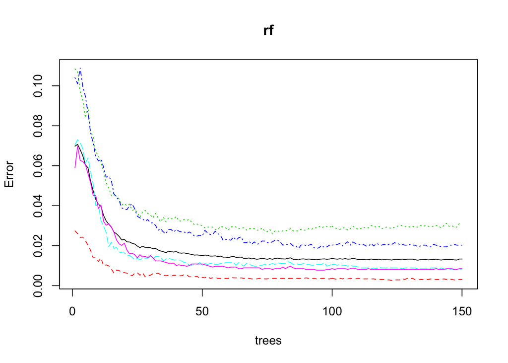

```r
plot(rf)
```

## Looks like setting ntree to 150 works as everything stablies by then

## Now tune the tree

```
## mtry = 3  OOB error = 1.33%
## Searching left ...
## mtry = 6     OOB error = 1.54%
## -0.1584699 0.05
## Searching right ...
## mtry = 1     OOB error = 3.19%
## -1.393443 0.05
```

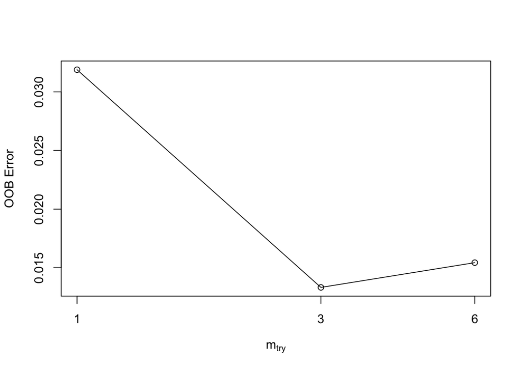

```r
t <- tuneRF(train[,-10],train[,10],stepFactor = 0.5,plot = TRUE,ntreeTry = 150,trace=TRUE,improve=0.05)
```

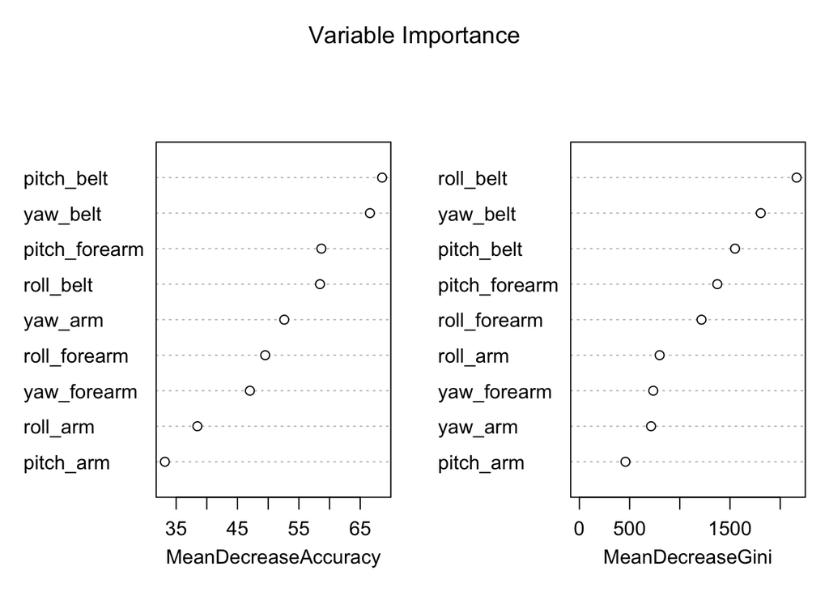

```r
varImpPlot(rf, main = "Variable Importance")
```

```r
importance(rf)
```

```
##                      A        B        C        D        E
## roll_forearm  35.12746 42.16592 63.50495 42.26632 40.92886
## pitch_forearm 33.90060 42.29278 49.18711 57.73113 47.60792
## yaw_forearm   34.03484 33.81100 39.20090 35.96642 36.98461
## roll_arm      23.00663 32.31770 29.95594 33.18180 21.62419
## pitch_arm     16.21265 30.48892 28.46013 27.34852 26.93549
## yaw_arm       36.78457 33.54651 40.38625 37.34290 26.08007
## roll_belt     37.45323 48.18741 45.19511 39.27791 44.40727
## pitch_belt    39.75571 57.70027 52.08955 54.07971 38.80439
## yaw_belt      49.95631 55.38768 48.96865 54.96258 26.34527
##               MeanDecreaseAccuracy MeanDecreaseGini
## roll_forearm              49.51550        1216.2094
## pitch_forearm             58.66732        1373.7521
## yaw_forearm               47.01997         735.8750
## roll_arm                  38.46088         799.2636
## pitch_arm                 33.16656         458.8687
## yaw_arm                   52.62110         713.9774
## roll_belt                 58.44136        2163.7055
## pitch_belt                68.56654        1550.2170
## yaw_belt                  66.58024        1806.4747
```

## Looks like mtry set to 3 works minimizes error and

## all the model features are important to the success of the model so simple box plots work vey well

## Predict using the train set

```r
p1 <- predict(rf, train)
confusionMatrix(p1,train$classe)
```

```
## Confusion Matrix and Statistics
##
##           Reference
## Prediction    A    B    C    D    E
##          A 3846    0    0    0    0
##          B    0 2628    0    0    0
##          C    0    0 2420    0    0
##          D    0    0    0 2257    0
##          E    0    0    0    0 2584
##
## Overall Statistics
##
##                Accuracy : 1
##                  95% CI : (0.9997, 1)
##     No Information Rate : 0.28
##     P-Value [Acc > NIR] : < 2.2e-16
##
##                   Kappa : 1
##  Mcnemar's Test P-Value : NA
##
## Statistics by Class:
##
##                      Class: A Class: B Class: C Class: D Class: E
## Sensitivity              1.00   1.0000   1.0000   1.0000   1.0000
## Specificity              1.00   1.0000   1.0000   1.0000   1.0000
## Pos Pred Value           1.00   1.0000   1.0000   1.0000   1.0000
## Neg Pred Value           1.00   1.0000   1.0000   1.0000   1.0000
## Prevalence               0.28   0.1913   0.1762   0.1643   0.1881
## Detection Rate           0.28   0.1913   0.1762   0.1643   0.1881
## Detection Prevalence     0.28   0.1913   0.1762   0.1643   0.1881
## Balanced Accuracy        1.00   1.0000   1.0000   1.0000   1.0000
```

## Predict using the test set

```r
p2 <- predict(rf, test)
confusionMatrix(p2,test$classe)
```

```
## Confusion Matrix and Statistics
##
##           Reference
## Prediction    A    B    C    D    E
##          A 1731    5    0    0    0
##          B    3 1141   12    0    1
##          C    0   23  988    4    3
##          D    0    0    1  953    7
##          E    0    0    1    2 1012
##
## Overall Statistics
##
##                Accuracy : 0.9895
##                  95% CI : (0.9865, 0.9919)
##     No Information Rate : 0.2945
##     P-Value [Acc > NIR] : < 2.2e-16
##
##                   Kappa : 0.9866
##  Mcnemar's Test P-Value : NA
##
## Statistics by Class:
##
##                      Class: A Class: B Class: C Class: D Class: E
## Sensitivity            0.9983   0.9760   0.9860   0.9937   0.9892
## Specificity            0.9988   0.9966   0.9939   0.9984   0.9994
## Pos Pred Value         0.9971   0.9862   0.9705   0.9917   0.9970
## Neg Pred Value         0.9993   0.9941   0.9971   0.9988   0.9977
## Prevalence             0.2945   0.1986   0.1702   0.1629   0.1738
## Detection Rate         0.2940   0.1938   0.1678   0.1619   0.1719
## Detection Prevalence   0.2949   0.1965   0.1729   0.1632   0.1724
## Balanced Accuracy      0.9985   0.9863   0.9899   0.9961   0.9943
```

## looks like the accuracy is very high approximately 98.95%